# Single Species Example from Gulf of Alaska with Catchability Covariates RACE Bottom Trawl Survey

Dr. Curry J. Cunningham

January 23, 2018

# 1 Purpose

The purpose of this document is to describe how to generate a model-based index of abundance unsing the spatio-temporal delta-GLMM in the VAST package, while incorporating **catchability covariates**.

## 1.1 Background

**Catchability** covariates attempt to explain residual variance in either the **encounter probability** or **positive catch rate** components of the delta model, given conditions influencing observation uncertainty at the time of sampling. In this way **catchability** covariates which are represented at the haul level, may be contrasted with **density** covariates which attempt to explain the underlying spatial distribution of the observed species and are represented at the knot level.

### 1.1.1 Example notation

Within the delta-model, the linear predictor for encounter probability can be written as:
$$\begin{aligned}
p_1(i)=\beta_1(c_i,t_i)+\sum_{f=1}^{n_{\omega1}} L_{\omega1}(c_i,f)\omega1(s_i,f) + \sum_{f=1}^{n_{\epsilon1}} L_{\epsilon1}(c_i,f)\epsilon_1(s_i,f,t_i) \\ + \sum_{f=1}^{n_{\delta1}} L_{\delta1}(v_i,f)\delta_1(v_i,f) + \sum_{p=1}^{n_p} \gamma_1(c_i,t_i,p)X(x_i,t_i,p) + \sum_{k=1}^{n_k} \lambda(k)Q(i,k)
\end{aligned}$$
where $p_1(i)$ is the predicotr for observation $i$, $Q(i,k)$ are measured catchability covariates that explain variation in catchability and $\lambda_1(k)$ is the estimated impact of catchability covariates for this linear predictor, and $X(x_i,t_i,p)$ are measured **density** covariates that explain variation in density and $\gamma_1(c_i,t_i,p)$ is the estimated impact of density covariates.

## 1.2 Hypotheses

We will be testing two hypotheses: * Tow duration (measured in hours) influences the catchability of species in the survey, under the assumption that longer tows should increase encounter probability and/or the positive catch rate if individuals outswim the survey net but tire over time. + Note: Trawl distance (positively correlated with encounter probability) is already accounted for when effort is calculated as area swept (square km). * Measured gear temperature influences catchability, due to potential shifts in the vertical distribution of species.

Specifics of this Example:

- Uses [RACE](https://www.afsc.noaa.gov/RACE/groundfish/bottom%20trawl%20surveys.php) bottom trawl survey data.
  - Data are available from the /data folder
- Single species implementation.
- Gulf of Alaska survey data.
- Haul-level catchability covariates: (1) tow duration (hours), (2) gear temperature.

# 2 Setup

## 2.1 Install required packages

```r
devtools::install_github("nwfsc-assess/geostatistical_delta-GLMM")
devtools::install_github("james-thorson/VAST")
devtools::install_github("james-thorson/utilities")
```

## 2.2 Load required packages

```r
require(dplyr)
require(VAST)
require(TMB)
require(FishData)
# require(tidyverse)
```

## 2.3 Setup model

### 2.3.1 Define species of interest (based on species code) and survey name.

Here are some examples to choose from:

| number | name | species.code | include | survey | Region |
| --- | --- | --- | --- | --- | --- |
| 1 | Pacific ocean perch | 30060 | Y | GOA | Gulf_of_Alaska |
| 2 | Pacific ocean perch | 30060 | Y | AI | Aleutian_Islands |
| 3 | Walleye pollock | 21740 | Y | GOA | Gulf_of_Alaska |
| 4 | Walleye pollock | 21740 | Y | AI | Aleutian_Islands |
| 5 | Pacific cod | 21720 | Y | GOA | Gulf_of_Alaska |
| 6 | Pacific cod | 21720 | N | EBS_SHELF | Eastern_Bering_Sea |
| 7 | Pacific cod | 21720 | Y | AI | Aleutian_Islands |
| 8 | Northern rockfish | 30420 | Y | GOA | Gulf_of_Alaska |
| 9 | Northern rockfish | 30420 | Y | AI | Aleutian_Islands |
| 10 | Dover sole | 10180 | Y | GOA | Gulf_of_Alaska |
| 11 | Big skate | 420 | Y | GOA | Gulf_of_Alaska |
| 12 | Atka mackerel | 21921 | Y | AI | Aleutian_Islands |
| 13 | Harlequin rockfish | 30535 | Y | GOA | Gulf_of_Alaska |
| 14 | Arrowtooth flounder | 10110 | Y | GOA | Gulf_of_Alaska |
| 15 | Arrowtooth flounder | 10110 | Y | EBS_SHELF | Eastern_Bering_Sea |
| 16 | Spiny dogfish | 310 | Y | GOA | Gulf_of_Alaska |

Example: Pacific Cod in the Gulf of Alaska

```r
species.codes = c(21720)
survey = "GOA"
combineSpecies = FALSE

if(survey=="GOA") { Region = 'Gulf_of_Alaska' }
if(survey=="EBS_SHELF") { Region = "Eastern_Bering_Sea" }
if(survey=="AI") { Region = "Aleutian Islands" }
```

### 2.3.2 Observation reference location settings

```r
lat_lon.def = "start"
```

### 2.3.3 Spatial settings

The following settings define the spatial resolution for the model (defined by number of knots `n_x`), and whether to use a grid or mesh approximation through the `Method` variable.

```r
Method = c("Grid", "Mesh", "Spherical_mesh")[2]
grid_size_km = 25
n_x = c(100, 250, 500, 1000, 2000)[1]
Kmeans_Config = list( "randomseed"=1, "nstart"=100, "iter.max"=1e3 )

#Strata Limits
#Basic - Single Area
strata.limits = data.frame(STRATA = c("All_areas"))

#VAST Version - latest!
Version = "VAST_v4_0_0"
```

### 2.3.4 Model settings

```r
bias.correct = FALSE

FieldConfig = c(Omega1 = 1, Epsilon1 = 1, Omega2 = 1, Epsilon2 = 1)
RhoConfig  = c(Beta1 = 0, Beta2 = 0, Epsilon1 = 0, Epsilon2 = 0)
OverdispersionConfig  = c(Delta1 = 0, Delta2 = 0)

#Observation Model
ObsModel = c(1,0)
```

### 2.3.5 Save settings

**DateFile** is the folder that will hold my model outputs.

```r
DateFile = paste0(getwd(), "/VAST_output/")

#Create directory
dir.create(DateFile, recursive=TRUE)
```

## 2.4 Specify model outputs

The following settings define what types of output we want to calculate.

```r
Options = c(SD_site_density = 0, SD_site_logdensity = 0,
            Calculate_Range = 1, Calculate_evenness = 0, Calculate_effective_area = 1,
            Calculate_Cov_SE = 0, Calculate_Synchrony = 0,
            Calculate_Coherence = 0)
```

# 3 Prepare the data

- Note: This section can be replace by function `create_VAST_input()`, from `R/create-VAST-input.r`

## 3.1 Load RACE data

To create the input data files for VAST model, first we must load RACE survey data. Two data files are necessary **(1)** catch data and **(2)** haul data.

### 3.1.1 Load and join data

Catch data

```r
catch = readRDS("data/race_base_catch.rds")

haul = readRDS("data/race_base_haul.rds")
haul = haul[haul$ABUNDANCE_HAUL == "Y", ]

# Join datasets
catchhaul = right_join(x = catch, y = haul, by = c("HAULJOIN"))

# Add in zero observations for catch weight, for no
# catches.
catchhaul.2 = FishData::add_missing_zeros(data_frame = catchhaul,
    unique_sample_ID_colname = "HAULJOIN", sample_colname = "WEIGHT",
    species_colname = "SPECIES_CODE", species_subset = species.codes,
    if_multiple_records = "First", Method = "Fast")
```

```
## Species to include: 21720
```

```
## Number of samples to include for each species: 31306
```

```
## Finished processing for 21720
```

```r
# Load and attach cruise info
cruise.info = read.csv("data/race_cruise_info.csv",
    header = TRUE, stringsAsFactors = FALSE)

catchhaul.3 = inner_join(x = catchhaul.2, y = cruise.info[,
    c("Cruise.Join.ID", "Year", "Survey")], by = c(CRUISEJOIN.x = "Cruise.Join.ID"))

# Limit to survey of interest
catchhaul.3 = catchhaul.3[catchhaul.3$Survey == survey,
    ]

# Aggregate multiple `species.codes`, if we are
# combining into a single index.
if (combineSpecies == TRUE) {
    catchhaul.4 = data.frame(catchhaul.3 %>% group_by(HAULJOIN) %>%
        mutate(WEIGHT = sum(WEIGHT, na.rm = TRUE)))
    # Since we have aggregated, only retain rows for
    # 1st listed species code
    catchhaul.5 = catchhaul.4[catchhaul.4$SPECIES_CODE ==
        species.codes[1], ]
} else {
    catchhaul.5 = catchhaul.3
}
```

## 3.2 Standardize data

In order to standardize the survey catch data, we must calculate effort as area swept per tow.

### 3.2.1 Calculate effort

Input effort is in $kilometers^2$

```r
catchhaul.5$effort = catchhaul.5$NET_WIDTH*catchhaul.5$DISTANCE_FISHED/1000
```

## 3.3 Add species names

First, we load the list describing both species names and `species.codes`

```r
species.code.data = read.csv("data/race_species_codes.csv",
                              header=TRUE, stringsAsFactors=FALSE)

#Next, join this to our overall survey data list
load.data = merge(x=catchhaul.5, y=species.code.data[,c("Species.Code","Common.Name")],
                       by.x="SPECIES_CODE", by.y="Species.Code")
```

## 3.4 Build `Data_Geostat`

Now, we will create the list `Data_Geostat` which is the input for the VAST model.

```r
Data_Geostat = NULL

if(length(species.codes) > 1) {
  Data_Geostat$spp = load.data$Common.Name
}
Data_Geostat$Catch_KG = as.numeric(load.data$WEIGHT)
Data_Geostat$Year = as.integer(load.data$Year)
Data_Geostat$Vessel = "missing"
Data_Geostat$AreaSwept_km2 = as.numeric(load.data$effort)
Data_Geostat$Pass = 0
```

### 3.4.1 Add **catchability** covariates to `Data_Geostat`

Here we can attach our two catchability covariates to our list of input data.

**Hypothesis #1:** Catchability is is influenced by tow duration in hours.

First, lets see what the distribution of tow durations look like…

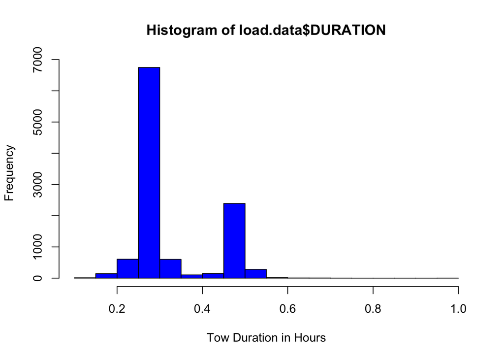

So there seems to be a break down between 0.5 hour and 0.25 hour tows, but when did they occurr?

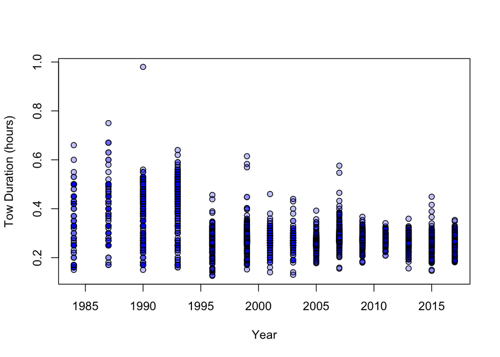

Ok lets attach these data to `Data_Geostat`

```r
Data_Geostat$Duration <- as.numeric(load.data$DURATION)
```

**Hypothesis #2:** Catchability is is influenced by gear temperature.

Again, lets see what the distribution of gear temperatures look like…

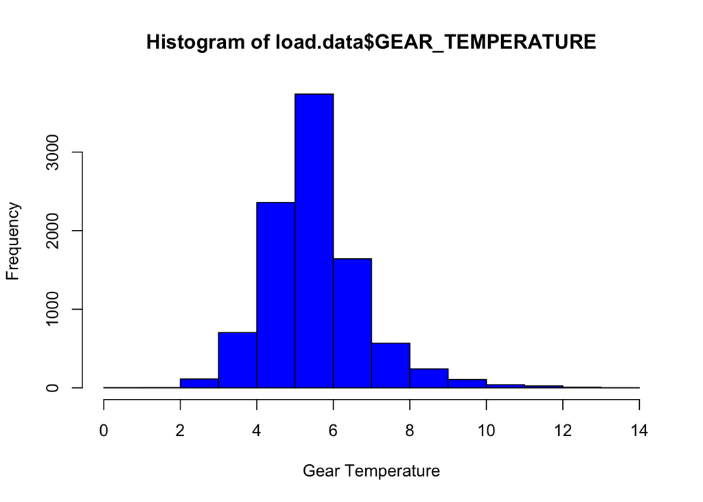

And lets add this to `Data_Geostat`

```r
Data_Geostat$Gear_Temperature <- as.numeric(load.data$GEAR_TEMPERATURE)
```

### 3.4.2 Define location of samples

Depending on `lat_lon.def` specification we will either use the **start**, **end**, or **mean** location recorded for a survey haul.

- Note: Using the starting location of each haul is probably best, as: `lat_lon.def="start"`.

```r
if(lat_lon.def=="start") {
  Data_Geostat$Lat = load.data$START_LATITUDE
  Data_Geostat$Lon = load.data$START_LONGITUDE
}
if(lat_lon.def=="end") {
  Data_Geostat$Lat = load.data$END_LATITUDE
  Data_Geostat$Lon = load.data$END_LONGITUDE
}
if(lat_lon.def=="mean") {
  Data_Geostat$Lat = rowMeans(cbind(load.data$START_LATITUDE,
                                     load.data$END_LATITUDE), na.rm=TRUE)

  Data_Geostat$Lon = rowMeans(cbind(load.data$START_LONGITUDE,
                                     load.data$END_LONGITUDE), na.rm=TRUE)
}
```

Next, we ensure this `Data_Geostat` is a proper data frame.

```r
Data_Geostat = data.frame(Data_Geostat)
```

To double check lets see how `Data_Geostat` looks…

```r
kable(head(Data_Geostat))
```

| Catch_KG | Year | Vessel | AreaSwept_km2 | Pass | Duration | Gear_Temperature | Lat | Lon |
| --- | --- | --- | --- | --- | --- | --- | --- | --- |
| 190.09 | 2005 | missing | 0.027696 | 0 | 0.281 | NA | 52.5579 | -169.783 |
| 30.89 | 2005 | missing | 0.020099 | 0 | 0.252 | 4.9 | 52.6384 | -169.781 |
| 242.18 | 2005 | missing | 0.024110 | 0 | 0.255 | 4.7 | 52.6713 | -169.428 |
| 39.92 | 2005 | missing | 0.020601 | 0 | 0.266 | 5.2 | 53.2410 | -168.072 |
| 16.18 | 2005 | missing | 0.019489 | 0 | 0.255 | 5.1 | 53.1677 | -167.981 |
| 61.22 | 2005 | missing | 0.021170 | 0 | 0.252 | 4.9 | 53.0684 | -167.671 |

## 3.5 Limit `Data_Geostat` to only tows with recorded `Gear_Temperature`

Upon closer inspection you will notice that some tows did not have a recorded `Gear_Temperature`, appearing as an `NA`. It appears to be ~ 13.7%

```r
nrow(Data_Geostat[is.na(Data_Geostat$Gear_Temperature),])/nrow(Data_Geostat)*100
```

```
## [1] 13.6865
```

Given we want to compare models fit to the same data, lets remove these tows without `Gear_Temperature` observations.

```r
Data_Geostat = Data_Geostat[!is.na(Data_Geostat$Gear_Temperature),]
```

### 3.5.1 Standardize the covariate data

```r
Data_Geostat$Duration <- Data_Geostat$Duration - mean(Data_Geostat$Duration)

Data_Geostat$Gear_Temperature <- Data_Geostat$Gear_Temperature - mean(Data_Geostat$Gear_Temperature)
```

## 3.6 Create the extrapolation grid

We also generate the extrapolation grid appropriate for a given region. For new regions, we use Region=“Other”.

- Note: We are not defining strata limits, but could do so based on latitude and longitude definitions.

```r
Extrapolation_List = SpatialDeltaGLMM::Prepare_Extrapolation_Data_Fn(Region = Region,
    strata.limits = strata.limits)
```

## 3.7 Create spatial list

Next, generate the information used for conducting spatio-temporal parameter estimation, bundled in list `Spatial_List`.

```r
Spatial_List = SpatialDeltaGLMM::Spatial_Information_Fn(grid_size_km = grid_size_km,
    n_x = n_x, Method = Method, Lon = Data_Geostat[,
        "Lon"], Lat = Data_Geostat[, "Lat"], Extrapolation_List = Extrapolation_List,
    randomseed = Kmeans_Config[["randomseed"]], nstart = Kmeans_Config[["nstart"]],
    iter.max = Kmeans_Config[["iter.max"]], DirPath = DateFile,
    Save_Results = TRUE)
```

## 3.8 Update `Data_Geostat` with knot references

We then associate each of our haul observations with its appropriate knot.

```r
Data_Geostat = cbind(Data_Geostat, knot_i = Spatial_List$knot_i)
```

# 4 Build and run models

Here we are going to build **3** models.

- **Null Model** which does **not** estimate catchability covariates.
- **Model 1** testing Hypothesis #1 with **tow duration** as a catchability covariate.
- **Model 2** testing Hypothesis #2 with **temperature** as a catchability covariate.

## 4.1 Null Model

First, create a subdirectory for the **Null Model**

```r
DateFile_null = paste0(DateFile,"Null/")
dir.create(DateFile_null)
```

Building and compiling:

- Note: in `Build_TMB_Fn()` whether to estimate **catchability** covariates is specified by the `Q_Config` argument, and whether to estimate **density** covariates by `CovConfig`.

```r
# Build
if (length(species.codes) > 1 & combineSpecies == FALSE) {
    # MULTISPECIES
    TmbData_null = VAST::Data_Fn(Version = Version,
        FieldConfig = FieldConfig, OverdispersionConfig = OverdispersionConfig,
        RhoConfig = RhoConfig, ObsModel = ObsModel,
        c_i = as.numeric(Data_Geostat[, "spp"]) - 1,
        b_i = Data_Geostat[, "Catch_KG"], a_i = Data_Geostat[,
            "AreaSwept_km2"], v_i = as.numeric(Data_Geostat[,
            "Vessel"]) - 1, s_i = Data_Geostat[, "knot_i"] -
            1, t_i = Data_Geostat[, "Year"], a_xl = Spatial_List$a_xl,
        MeshList = Spatial_List$MeshList, GridList = Spatial_List$GridList,
        Method = Spatial_List$Method, Options = Options)
} else {
    # SINGLE SPECIES
    TmbData_null = VAST::Data_Fn(Version = Version,
        FieldConfig = FieldConfig, OverdispersionConfig = OverdispersionConfig,
        RhoConfig = RhoConfig, ObsModel = ObsModel,
        c_i = rep(0, nrow(Data_Geostat)), b_i = Data_Geostat[,
            "Catch_KG"], a_i = Data_Geostat[, "AreaSwept_km2"],
        v_i = as.numeric(Data_Geostat[, "Vessel"]) -
            1, s_i = Data_Geostat[, "knot_i"] - 1,
        t_i = Data_Geostat[, "Year"], a_xl = Spatial_List$a_xl,
        MeshList = Spatial_List$MeshList, GridList = Spatial_List$GridList,
        Method = Spatial_List$Method, Options = Options)
}

# Compile TMB object
TmbList_null = VAST::Build_TMB_Fn(TmbData = TmbData_null,
    RunDir = DateFile_null, Version = Version, RhoConfig = RhoConfig,
    loc_x = Spatial_List$loc_x, Method = Method, Q_Config = FALSE,
    CovConfig = FALSE)
Obj_null = TmbList_null[["Obj"]]
```

Fit VAST model to the data by optimizing the TMB function.

```r
Opt_null = TMBhelper::Optimize(obj = Obj_null, lower = TmbList_null[["Lower"]],
                          upper = TmbList_null[["Upper"]], getsd = TRUE,
                          savedir = DateFile_null,
                          bias.correct = bias.correct, newtonsteps=2)
```

Save outputs from estimation

```r
Report_null = Obj_null$report()

Save_null = list("Opt"=Opt_null, "Report"=Report_null,
                 "ParHat"=Obj_null$env$parList(Opt_null$par),
                 "TmbData"=TmbData_null)

save(Save_null, file=paste0(DateFile_null,"Save.RData"))
```

## 4.2 Model 1

First, create a subdirectory for the **Model 1**

```r
DateFile_Mod1 = paste0(DateFile,"Model 1/")
dir.create(DateFile_Mod1)
```

Building and compiling:

`Q_ik` is the argument to Data_Fn for catchability covariates.

- Note: `Q_ik` expects a matrix so we specify `Q_ik=as.matrix(Data_Geostat[,'Duration'])`

```r
# Build
if (length(species.codes) > 1 & combineSpecies == FALSE) {
    # MULTISPECIES
    TmbData_Mod1 = VAST::Data_Fn(Version = Version,
        FieldConfig = FieldConfig, OverdispersionConfig = OverdispersionConfig,
        RhoConfig = RhoConfig, ObsModel = ObsModel,
        c_i = as.numeric(Data_Geostat[, "spp"]) - 1,
        b_i = Data_Geostat[, "Catch_KG"], a_i = Data_Geostat[,
            "AreaSwept_km2"], v_i = as.numeric(Data_Geostat[,
            "Vessel"]) - 1, s_i = Data_Geostat[, "knot_i"] -
            1, t_i = Data_Geostat[, "Year"], a_xl = Spatial_List$a_xl,
        MeshList = Spatial_List$MeshList, GridList = Spatial_List$GridList,
        Method = Spatial_List$Method, Options = Options,
        Q_ik = as.matrix(Data_Geostat[, "Duration"]))
} else {
    # SINGLE SPECIES
    TmbData_Mod1 = VAST::Data_Fn(Version = Version,
        FieldConfig = FieldConfig, OverdispersionConfig = OverdispersionConfig,
        RhoConfig = RhoConfig, ObsModel = ObsModel,
        c_i = rep(0, nrow(Data_Geostat)), b_i = Data_Geostat[,
            "Catch_KG"], a_i = Data_Geostat[, "AreaSwept_km2"],
        v_i = as.numeric(Data_Geostat[, "Vessel"]) -
            1, s_i = Data_Geostat[, "knot_i"] - 1,
        t_i = Data_Geostat[, "Year"], a_xl = Spatial_List$a_xl,
        MeshList = Spatial_List$MeshList, GridList = Spatial_List$GridList,
        Method = Spatial_List$Method, Options = Options,
        Q_ik = as.matrix(Data_Geostat[, "Duration"]))
}

# Compile TMB object
TmbList_Mod1 = VAST::Build_TMB_Fn(TmbData = TmbData_Mod1,
    RunDir = DateFile_Mod1, Version = Version, RhoConfig = RhoConfig,
    loc_x = Spatial_List$loc_x, Method = Method, Q_Config = TRUE,
    CovConfig = FALSE)
Obj_Mod1 = TmbList_Mod1[["Obj"]]
```

Fit VAST model to the data by optimizing the TMB function.

```r
Opt_Mod1 = TMBhelper::Optimize(obj = Obj_Mod1, lower = TmbList_Mod1[["Lower"]],
                          upper = TmbList_Mod1[["Upper"]], getsd = TRUE,
                          savedir = DateFile_Mod1,
                          bias.correct = bias.correct, newtonsteps=2)
```

Save outputs from estimation

```r
Report_Mod1 = Obj_Mod1$report()

Save_Mod1 = list("Opt"=Opt_Mod1, "Report"=Report_Mod1,
                 "ParHat"=Obj_Mod1$env$parList(Opt_Mod1$par),
                 "TmbData"=TmbData_Mod1)

save(Save_Mod1, file=paste0(DateFile_Mod1,"Save.RData"))
```

## 4.3 Model 2

First, create a subdirectory for the **Model 2**

```r
DateFile_Mod2 = paste0(DateFile,"Model 2/")
dir.create(DateFile_Mod2)
```

Building and compiling:

`Q_ik` is the argument to Data_Fn for catchability covariates.

- Note: `Q_ik` expects a matrix so we specify `Q_ik=as.matrix(Data_Geostat[,'Gear_Temperature'])`

```r
# Build
if (length(species.codes) > 1 & combineSpecies == FALSE) {
    # MULTISPECIES
    TmbData_Mod2 = VAST::Data_Fn(Version = Version,
        FieldConfig = FieldConfig, OverdispersionConfig = OverdispersionConfig,
        RhoConfig = RhoConfig, ObsModel = ObsModel,
        c_i = as.numeric(Data_Geostat[, "spp"]) - 1,
        b_i = Data_Geostat[, "Catch_KG"], a_i = Data_Geostat[,
            "AreaSwept_km2"], v_i = as.numeric(Data_Geostat[,
            "Vessel"]) - 1, s_i = Data_Geostat[, "knot_i"] -
            1, t_i = Data_Geostat[, "Year"], a_xl = Spatial_List$a_xl,
        MeshList = Spatial_List$MeshList, GridList = Spatial_List$GridList,
        Method = Spatial_List$Method, Options = Options,
        Q_ik = as.matrix(Data_Geostat[, "Gear_Temperature"]))
} else {
    # SINGLE SPECIES
    TmbData_Mod2 = VAST::Data_Fn(Version = Version,
        FieldConfig = FieldConfig, OverdispersionConfig = OverdispersionConfig,
        RhoConfig = RhoConfig, ObsModel = ObsModel,
        c_i = rep(0, nrow(Data_Geostat)), b_i = Data_Geostat[,
            "Catch_KG"], a_i = Data_Geostat[, "AreaSwept_km2"],
        v_i = as.numeric(Data_Geostat[, "Vessel"]) -
            1, s_i = Data_Geostat[, "knot_i"] - 1,
        t_i = Data_Geostat[, "Year"], a_xl = Spatial_List$a_xl,
        MeshList = Spatial_List$MeshList, GridList = Spatial_List$GridList,
        Method = Spatial_List$Method, Options = Options,
        Q_ik = as.matrix(Data_Geostat[, "Gear_Temperature"]))
}

# Compile TMB object
TmbList_Mod2 = VAST::Build_TMB_Fn(TmbData = TmbData_Mod2,
    RunDir = DateFile_Mod2, Version = Version, RhoConfig = RhoConfig,
    loc_x = Spatial_List$loc_x, Method = Method, Q_Config = TRUE,
    CovConfig = FALSE)
Obj_Mod2 = TmbList_Mod2[["Obj"]]
```

Fit VAST model to the data by optimizing the TMB function.

```r
Opt_Mod2 = TMBhelper::Optimize(obj = Obj_Mod2, lower = TmbList_Mod2[["Lower"]],
                          upper = TmbList_Mod2[["Upper"]], getsd = TRUE,
                          savedir = DateFile_Mod2,
                          bias.correct = bias.correct, newtonsteps=2)
```

Save outputs from estimation

```r
Report_Mod2 = Obj_Mod2$report()

Save_Mod2 = list("Opt"=Opt_Mod2, "Report"=Report_Mod2,
                 "ParHat"=Obj_Mod2$env$parList(Opt_Mod2$par),
                 "TmbData"=TmbData_Mod1)

save(Save_Mod2, file=paste0(DateFile_Mod2,"Save.RData"))
```

# 5 Compare Models

## 5.1 Check convergence

To evaluate convergence of our three candidate models we will look at convergence and the maximum gradient, which can both be accessed from the **Opt** object as **Opt$convergence** and **Opt$max_gradient**.

- Note: **Opt$convergence = 0** indicates relative convergence.

```r
temp.table = NULL
temp.table$name = c('Null Model', 'Model 1', 'Model 2')
temp.table$effect = c('None','Tow Duration', 'Gear Temperature')
temp.table$convergence = c(Opt_null$convergence,
                           Opt_Mod1$convergence,
                           Opt_Mod2$convergence)
temp.table$max_gradient = c(Opt_null$max_gradient,
                            Opt_Mod1$max_gradient,
                            Opt_Mod2$max_gradient)
temp.table = data.frame(temp.table)
names(temp.table) = c('Model Name','Catchability Covariate','Convergence','Maximum Gradient')
#Print the table
# kable(temp.table)
pander::pandoc.table(temp.table)
```

```
##
## ----------------------------------------------------------------------
##  Model Name   Catchability Covariate   Convergence   Maximum Gradient
## ------------ ------------------------ ------------- ------------------
##  Null Model            None                 0            1.36e-08
##
##   Model 1          Tow Duration             1           4.199e-12
##
##   Model 2        Gear Temperature           1           2.563e-08
## ----------------------------------------------------------------------
```

## 5.2 Covariate effects

### 5.2.1 **Model 1** with tow duration

We can recall that the parameters describing the effect of **catchability** covariates on the encounter probability component of our delta-model is $\lambda_1(k)$, and the effect on the positive catch rate component is $\lambda_2(k)$.

So, in our mode output below we are intersted in:

- `lambda1_k` - Effect of tow duration on encounter probability.
- `lambda2_k` - Effect of tow duration on positive catch rate.

```r
Opt_Mod1$SD
```

```
## sdreport(.) result
##                Estimate Std. Error
## ln_H_input    0.6484959 0.20259082
## ln_H_input    0.5634271 0.20730304
## beta1_ct      0.7680569 0.40179994
## beta1_ct      1.0858278 0.42729033
## beta1_ct      0.9671968 0.42350946
## beta1_ct      0.9667924 0.40278154
## beta1_ct      0.6279436 0.38945982
## beta1_ct      0.1408662 0.38715497
## beta1_ct     -0.4156029 0.40792366
## beta1_ct      0.0686393 0.38842702
## beta1_ct      0.1100164 0.38795782
## beta1_ct      0.1488958 0.38817106
## beta1_ct      0.5324485 0.38864904
## beta1_ct      0.5376343 0.39148341
## beta1_ct      0.5408886 0.39379393
## beta1_ct      0.4934737 0.38855193
## beta1_ct     -0.3041748 0.39275511
## lambda1_k     0.4918490 0.62780091
## L_omega1_z    1.4661828 0.16984990
## L_epsilon1_z -0.5688669 0.06042287
## logkappa1    -4.4566656 0.12560931
## beta2_ct      7.3688465 0.21948876
## beta2_ct      7.2870009 0.23946976
## beta2_ct      7.3712636 0.23901979
## beta2_ct      7.5303185 0.21885501
## beta2_ct      7.4170807 0.19941634
## beta2_ct      7.2773583 0.20077707
## beta2_ct      6.8887212 0.22349751
## beta2_ct      7.0803673 0.20186147
## beta2_ct      7.0839154 0.20196467
## beta2_ct      6.9952751 0.20132804
## beta2_ct      7.4203081 0.20019487
## beta2_ct      7.4101633 0.20223139
## beta2_ct      7.4970214 0.20616636
## beta2_ct      7.1660984 0.19890412
## beta2_ct      6.7951060 0.21305041
## lambda2_k    -0.3634464 0.58631354
## L_omega2_z   -0.5456585 0.07720787
## L_epsilon2_z  0.3362267 0.04953504
## logkappa2    -4.6092706 0.17616916
## logSigmaM     0.4572419 0.00950848
## Maximum gradient component: 4.19931e-12
```

### 5.2.2 **Model 2** with gear temperature

For our second model we are interested in:

- `lambda1_k` - Effect of gear temperature on encounter probability.
- `lambda2_k` - Effect of gear temperature on positive catch rate.

```r
Opt_Mod2$SD
```

```
## sdreport(.) result
##                 Estimate Std. Error
## ln_H_input    0.64276446 0.20830246
## ln_H_input    0.57909883 0.21117917
## beta1_ct      0.63215573 0.39588356
## beta1_ct      1.04666313 0.42067813
## beta1_ct      1.02803384 0.42138926
## beta1_ct      1.02592779 0.39569742
## beta1_ct      0.60599153 0.39372255
## beta1_ct      0.24160166 0.39140561
## beta1_ct     -0.60247732 0.41502251
## beta1_ct     -0.11135198 0.39252041
## beta1_ct     -0.00265541 0.39163235
## beta1_ct      0.26714766 0.39292596
## beta1_ct      0.64598671 0.39304430
## beta1_ct      0.51793732 0.39570538
## beta1_ct      0.56333282 0.39773466
## beta1_ct      0.27594981 0.39294646
## beta1_ct     -0.43800222 0.39707041
## lambda1_k     0.31063717 0.02984861
## L_omega1_z   -1.41051662 0.16305215
## L_epsilon1_z  0.60480266 0.06086523
## logkappa1    -4.49707522 0.12051365
## beta2_ct      7.47537289 0.16360023
## beta2_ct      7.37726817 0.18462278
## beta2_ct      7.34745169 0.19382767
## beta2_ct      7.53851871 0.15945634
## beta2_ct      7.45916898 0.16224347
## beta2_ct      7.20956566 0.16406694
## beta2_ct      7.01202284 0.18755120
## beta2_ct      7.25056800 0.16444894
## beta2_ct      7.19717303 0.16323875
## beta2_ct      6.92138727 0.16391740
## beta2_ct      7.35411279 0.16219316
## beta2_ct      7.44073572 0.16496791
## beta2_ct      7.51679772 0.16873511
## beta2_ct      7.34190803 0.16167044
## beta2_ct      6.87617410 0.17714887
## lambda2_k    -0.19301542 0.02346359
## L_omega2_z   -0.50752521 0.07026177
## L_epsilon2_z -0.34358753 0.05022916
## logkappa2    -4.35333289 0.19186672
## logSigmaM     0.45065096 0.00957048
## Maximum gradient component: 2.56291e-08
```

## 5.3 Compare AIC across models

One way to compare across our candidate models with and without catchability covariates is to use AIC. The AIC for each model can be accessed from **Opt$AIC**.

Lets compare AIC across models…

```r
aic.table <- NULL
aic.table$name = c('Null Model', 'Model 1', 'Model 2')
aic.table$effect = c('None','Tow Duration', 'Gear Temperature')
aic.table$AIC = c(Opt_null$AIC, Opt_Mod1$AIC, Opt_Mod2$AIC)
#Calculate dAIC
aic.table$dAIC <- aic.table$AIC - min(aic.table$AIC)
#Data frame
aic.table <- data.frame(aic.table)
names(aic.table) <- c('Model Name', 'Catchability Covariate', 'AIC', 'dAIC')
#Print the table
kable(aic.table)
```

| Model Name | Catchability Covariate | AIC | dAIC |
| --- | --- | --- | --- |
| Null Model | None | 66056.0 | 178.225 |
| Model 1 | Tow Duration | 66059.0 | 181.229 |
| Model 2 | Gear Temperature | 65877.7 | 0.000 |

```r
# pander::pandoc.table(aic.table)
```

# 6 General conclusions

Here are some general conclusions regarding GOA Pacific Cod:

- For **Model 1** the effect of tow duration is highly uncertain with CV>1 estimated for effects of this covariate on both encounter probability `lambda1_k` and positive catch rate `lambda2_k`.
- For **Model 2** estimated catchability covariate effects have lower uncertainty
- Encounter probability is estimated to **increase** with gear temperature.
- Positive catch rate is estimated to **decrease** with gear temperature.
- It appears that **Model 2** which incorporates **gear temperature** as a **catchability** covariate provides a more parsimonious fit to the survey data.
- It should be noted that a Poisson-link delta-model may be a better way to correct for differences in tow duration.
- This may be specified with `ObsModel = c(1,1)`.

# 7 Specifying **catchability** covariates for positive catch rate **only**

Given your assumptions about the sampling process, it may make more sense to estimate the effect of the **catchability** covariates on the **positive catch rate** component of the delta-model only. To do so, we must:

- Modify the `Tmb_List_...` object by…
- Extracting the `$Map` object, as: `Map = TmbList$Map`
- Modifying `Map` to turn off estimation of `lambda1_k`, as: `Map[["lambda1_k"]] = rep(NA, length(TmbList$Parameters$lambda1_k))`
- Recompile the `TmbList_...` with `VAST::BuildTMB_Fn()`

As an example we will update, recompile, and re-fit **Model 1** and **Model 2**, so that the effect of **tow duration** and **gear temperature** is only linked to **positive catch rate**. We will refer to these as **Model 1b** and **Model 2b**.

## 7.1 **Model 1b:** tow duration effect on positive catch rate **only**

First, lets take the existing `TmbList_Mod1` from **Model 1** and extract `$Map`

```r
Map_1b = TmbList_Mod1$Map
```

Next, lets turn **off** estimation of `lambda1_k`, lambda_k being the effect of **catchability** covariates, and **1** indicating this is for the **encounter probability** component of the delta-model.

```r
Map_1b[["lambda1_k"]] = factor(rep(NA, length(TmbList_Mod1$Parameters$lambda1_k)))
```

Finally, lets recompile the model.

```r
#New file
DateFile_Mod1b = paste0(DateFile,"/Model 1b/")
dir.create(DateFile_Mod1b)

#Recompile
TmbList_Mod1b = VAST::Build_TMB_Fn(TmbData = TmbData_Mod1, RunDir = DateFile_Mod1b,
                                Version = Version, RhoConfig = RhoConfig,
                                loc_x = Spatial_List$loc_x,
                                Method = Method, Q_Config=TRUE, CovConfig=FALSE, Map=Map_1b)
```

```
## Note: Using Makevars in /Users/curryc2/.R/Makevars
```

```
## List of estimated fixed and random effects:
```

```
##     Coefficient_name Number_of_coefficients
## 1           beta1_ct                     15
## 2           beta2_ct                     15
## 3       L_epsilon1_z                      1
## 4       L_epsilon2_z                      1
## 5         L_omega1_z                      1
## 6         L_omega2_z                      1
## 7          lambda2_k                      1
## 8         ln_H_input                      2
## 9          logkappa1                      1
## 10         logkappa2                      1
## 11         logSigmaM                      1
## 12 Epsiloninput1_sft                   3944
## 13 Epsiloninput2_sft                   3944
## 14    Omegainput1_sf                    116
```

[output cut: 17 more lines]

```r
Obj_Mod1b = TmbList_Mod1b$Obj
```

Fit VAST model to the data by optimizing the TMB function.

```r
Opt_Mod1b = TMBhelper::Optimize(obj = Obj_Mod1b, lower = TmbList_Mod1b[["Lower"]],
                          upper = TmbList_Mod1b[["Upper"]], getsd = TRUE,
                          savedir = DateFile_Mod1b,
                          bias.correct = bias.correct, newtonsteps=2)
```

Save outputs from estimation

```r
Report_Mod1b = Obj_Mod1b$report()

Save_Mod1b = list("Opt"=Opt_Mod1b, "Report"=Report_Mod1b,
                 "ParHat"=Obj_Mod1b$env$parList(Opt_Mod1b$par),
                 "TmbData"=TmbData_Mod1)

save(Save_Mod1b, file=paste0(DateFile_Mod1b,"Save.RData"))
```

## 7.2 **Model 2b:** gear temperature effect on positive catch rate **only**

First, lets take the existing `TmbList_Mod2` from **Model 2** and extract `$Map`

```r
Map_2b = TmbList_Mod2$Map
```

Next, lets turn **off** estimation of `lambda1_k`, lambda_k being the effect of **catchability** covariates, and **1** indicating this is for the **encounter probability** component of the delta-model.

```r
Map_2b[["lambda1_k"]] = factor(rep(NA, length(TmbList_Mod2$Parameters$lambda1_k)))
```

Finally, lets recompile the model.

```r
#New file
DateFile_Mod2b = paste0(DateFile,"/Model 2b/")
dir.create(DateFile_Mod2b)

#Recompile
TmbList_Mod2b = VAST::Build_TMB_Fn(TmbData = TmbData_Mod2, RunDir = DateFile_Mod2b,
                                Version = Version, RhoConfig = RhoConfig,
                                loc_x = Spatial_List$loc_x,
                                Method = Method, Q_Config=TRUE, CovConfig=FALSE, Map=Map_2b)
```

```
## Note: Using Makevars in /Users/curryc2/.R/Makevars
```

```
## List of estimated fixed and random effects:
```

```
##     Coefficient_name Number_of_coefficients
## 1           beta1_ct                     15
## 2           beta2_ct                     15
## 3       L_epsilon1_z                      1
## 4       L_epsilon2_z                      1
## 5         L_omega1_z                      1
## 6         L_omega2_z                      1
## 7          lambda2_k                      1
## 8         ln_H_input                      2
## 9          logkappa1                      1
## 10         logkappa2                      1
## 11         logSigmaM                      1
## 12 Epsiloninput1_sft                   3944
## 13 Epsiloninput2_sft                   3944
## 14    Omegainput1_sf                    116
```

[output cut: 17 more lines]

```r
Obj_Mod2b = TmbList_Mod2b$Obj
```

Fit VAST model to the data by optimizing the TMB function.

```r
Opt_Mod2b = TMBhelper::Optimize(obj = Obj_Mod2b, lower = TmbList_Mod2b[["Lower"]],
                          upper = TmbList_Mod2b[["Upper"]], getsd = TRUE,
                          savedir = DateFile_Mod2b,
                          bias.correct = bias.correct, newtonsteps=2)
```

Save outputs from estimation

```r
Report_Mod2b = Obj_Mod2b$report()

Save_Mod2b = list("Opt"=Opt_Mod2b, "Report"=Report_Mod2b,
                 "ParHat"=Obj_Mod2b$env$parList(Opt_Mod2b$par),
                 "TmbData"=TmbData_Mod2)

save(Save_Mod2b, file=paste0(DateFile_Mod2b,"Save.RData"))
```

## 7.3 Convergence of five models

```r
temp.table = NULL
temp.table$name = c('Null Model', 'Model 1', 'Model 2', 'Model 1b', 'Model 2b')
temp.table$effect = c('None','Tow Duration', 'Gear Temperature', 'Tow Duration (PCR-only)', 'Gear Temperature (PCR-only)')
temp.table$convergence = c(Opt_null$convergence,
                           Opt_Mod1$convergence,
                           Opt_Mod2$convergence,
                           Opt_Mod1b$convergence,
                           Opt_Mod2b$convergence)
temp.table$max_gradient = c(Opt_null$max_gradient,
                            Opt_Mod1$max_gradient,
                            Opt_Mod2$max_gradient,
                            Opt_Mod1b$max_gradient,
                            Opt_Mod2b$max_gradient)
temp.table = data.frame(temp.table)
names(temp.table) = c('Model Name','Catchability Covariate','Convergence','Maximum Gradient')
#Print the table
# kable(temp.table)
pander::pandoc.table(temp.table)
```

```
##
## ---------------------------------------------------------------------------
##  Model Name     Catchability Covariate      Convergence   Maximum Gradient
## ------------ ----------------------------- ------------- ------------------
##  Null Model              None                    0            1.36e-08
##
##   Model 1            Tow Duration                1           4.199e-12
##
##   Model 2          Gear Temperature              1           2.563e-08
##
##   Model 1b      Tow Duration (PCR-only)          0           9.055e-09
##
##   Model 2b    Gear Temperature (PCR-only)        1            2.26e-07
## ---------------------------------------------------------------------------
```

## 7.4 Compare AIC for five models

Lets compare AIC across models…

```r
aic.table <- NULL
aic.table$name = c('Null Model', 'Model 1', 'Model 2', 'Model 1b', 'Model 2b')
aic.table$effect = c('None','Tow Duration', 'Gear Temperature', 'Tow Duration (PCR-only)', 'Gear Temperature (PCR-only)')
aic.table$AIC = c(Opt_null$AIC, Opt_Mod1$AIC, Opt_Mod2$AIC, Opt_Mod1b$AIC, Opt_Mod2b$AIC)
#Calculate dAIC
aic.table$dAIC <- aic.table$AIC - min(aic.table$AIC)
#Data frame
aic.table <- data.frame(aic.table)
names(aic.table) <- c('Model Name', 'Catchability Covariate', 'AIC', 'dAIC')
#Print the table
kable(aic.table)
```

| Model Name | Catchability Covariate | AIC | dAIC |
| --- | --- | --- | --- |
| Null Model | None | 66056.0 | 178.225 |
| Model 1 | Tow Duration | 66059.0 | 181.229 |
| Model 2 | Gear Temperature | 65877.7 | 0.000 |
| Model 1b | Tow Duration (PCR-only) | 66057.6 | 179.841 |
| Model 2b | Gear Temperature (PCR-only) | 65990.9 | 113.125 |

```r
# pander::pandoc.table(aic.table)
```